# Visualizing Decision Trees

# Gini Impurity Example

### Weather Condition: Play Golf Decision

$$\begin{array}{c|c} Day & Outlook & Temperature & Humidity & Wind & Decision \\ \hline 1 & Sunny & Hot & High & Weak & No \\ \hline 2 & Sunny & Hot & High & Strong & No \\ \hline 3 & Overcast & Hot & High & Weak & Yes \\ \hline 4 & Rainy & Mild & High & Weak & Yes \\ \hline 5 & Rainy & Cold & Normal & Weak & Yes \\ \hline 6 & Rainy & Cold & Normal & Strong & No \\ \hline 7 & Overcast & Cold & Normal & Strong & Yes \\ \hline 8 & Sunny & Mild & High & Weak & No \\ \hline 9 & Sunny & Cold & Normal & Weak & Yes \\ \hline 10 & Rainy & Mild & Normal & Weak & Yes \\ \hline 11 & Sunny & Mild & Normal & Strong & Yes \end{array}$$

### Outlook

$$\begin{array}{c|c} Outlook & Yes & No & Instances \\ \hline Sunny & 2 & 3 & 5 \\ \hline Overcast & 2 & 0 & 2 \\ \hline Rainy & 3 & 1 & 4 \\ \end{array}$$

### Temperature

$$\begin{array}{c|c} Temperature & Yes & No & Instances \\ \hline Hot & 1 & 2 & 3 \\ \hline Mild & 3 & 1 & 4 \\ \hline Cold & 3 & 1 & 4 \\ \end{array}$$

### Humidity

$$\begin{array}{c|c} Humidity & Yes & No & Instances \\ \hline High & 2 & 3 & 5 \\ \hline Normal & 5 & 1 & 6 \end{array}$$

### Wind

$$\begin{array}{c|c} Wind & Yes & No & Instances \\ \hline Weak & 5 & 2 & 7 \\ \hline Strong & 2 & 2 & 4 \\ \end{array}$$

# For All our Variables We now Want to calculate their Gini Index To Determine The Root Node

Below is just for the Condition Variable but you would do this for each variables

## Sunny vs Other

$$\begin{array}{c|c} & Yes & No & Instances \\ \hline Sunny & 2 & 3 & 5 \\ \hline Other & 5 & 1 & 6 \end{array}$$

#### Gini Impurity

$$ Sunny = 1 - (\frac{2}{2+3})^{2} - (\frac{3}{2+3})^{2}$$

$$ GR = 0.48 $$

$$ Other = 1 - (\frac{5}{5+1})^{2} - (\frac{1}{5+1})^{2}$$

$$ GL = 0.278$$

#### Weighted Average

$$J(k,t_k) = \frac{m_{left}}{m}G_{left} + \frac{m_{right}}{m}G_{right}$$

$$\frac{5}{5+6}0.48 + \frac{6}{5+6}0.278$$

$$= 0.369 $$

## Overcast vs Other

$$\begin{array}{c|c} & Yes & No & Instances \\ \hline Overcast & 2 & 0 & 2 \\ \hline Other & 5 & 4 & 9 \end{array}$$

#### Gini Impurity

$$ Overcast = 1 - (\frac{2}{2+0})^{2} - (\frac{0}{2+0})^{2}$$

$$ GR = 0 $$

$$ Other = 1 - (\frac{5}{5+4})^{2} - (\frac{4}{5+4})^{2}$$

$$ GL = 0.49$$

#### Weighted Average

$$J(k,t_k) = \frac{m_{left}}{m}G_{left} + \frac{m_{right}}{m}G_{right}$$

$$\frac{2}{2+9}0 + \frac{9}{2+9}0.49$$

$$= 0.4 $$

## Rainy vs Other

$$\begin{array}{c|c} & Yes & No & Instances \\ \hline Rainy & 3 & 1 & 4 \\ \hline Other & 4 & 3 & 7 \end{array}$$

#### Gini Impurity

$$ Rainy = 1 - (\frac{3}{1+3})^{2} - (\frac{1}{1+3})^{2}$$

$$ GR = 0.375 $$

$$ Other = 1 - (\frac{4}{4+3})^{2} - (\frac{3}{4+3})^{2}$$

$$ GL = 0.49$$

#### Weighted Average

$$J(k,t_k) = \frac{m_{left}}{m}G_{left} + \frac{m_{right}}{m}G_{right}$$

$$\frac{4}{4+7}0.375 + \frac{7}{4+7}0.49$$

$$= 0.448 $$

## Decision For our Root Node Is Outlook Sunny

In terms of Weighted Gini Index Values Outlook Sunny results in the Purest nodes

```python
Image('MultipleRoots.png')
```

[figure not shown]

## Interpreation

1. We can see from our calculation that Outlook_Sunny contained the lowest impurity so it became our root node.
   - Now we need to know how well Temperature, Humidity, and Wind separate the Decision in our internal node
   - Once it has successfully split the training set in two, it splits the subsets using the same logic, then the sub-subsets and so on, recursively.
1. Just like before we calculate the gini impurity on these nodes using Temperature, Humidity, and Wind
- The identifier with the lowest gini impurity will be used to separate these nodes
1. Notably, if the node iteself has the lowest gini score then there is no point in separating that node any more
- This becomes our leaf node
- It stops recursing once it reaches the maximum depth

# Prediction

## Given the Data Below Was Golf Played

#### Run the data through the tree below

$$\begin{array}{c|c} Outlook & Temperature & Humidity & Wind & Decision \\ \hline Sunny & Hot & Normal & Weak & ? \end{array}$$

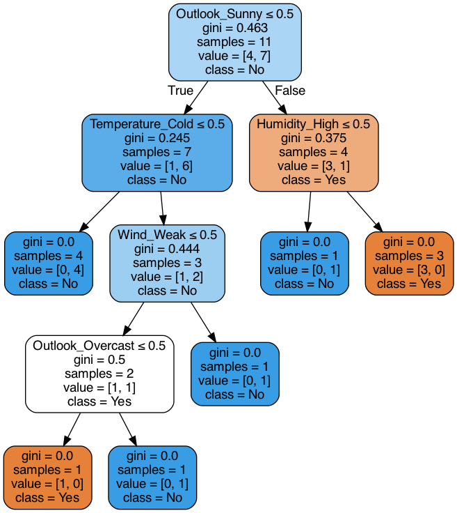

```python
Image('DTFull.png')
```